# WIC app sandbox

# the free entry interface

Here the user is going to be given combos of materials and dispositions. They can adjust the tons and end-of-life mileage. Then they will be shown the weights and impacts.

For objects specific to this interface, I will use the prefix fe_. E.g. not “data” but “fe_data”.

Fooling around with some colors.

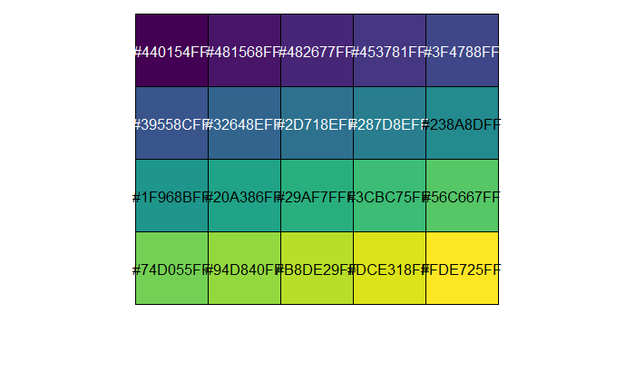

[figure not shown]

```r
# importing impact factor data
fe_no_records <- 2  #this is just a limiter during app development
impact_factors <-
  readRDS(
    \../oregon_deq/projects/arr_scenarios_deq_factors/intermediate_output/impact_factors_deq.Rdata\
    ) %>%
  as.data.frame()

# creating a blank small set of material-disposition combinations to work with
# during testing
fe_mat_disp_combos <-
  impact_factors %>%
  filter(LCstage == \endOfLife\) %>%
  sample_n(fe_no_records) %>%
  unique() %>%
  select(material, disposition, impliedMiles) %>%
  mutate(
    baseline_tons=round(runif(n=fe_no_records, min=0, max=10),1),
    baseline_miles=impliedMiles,
    alternative_tons=round(runif(n=fe_no_records, min=0, max=10),1),
    alternative_miles=impliedMiles
  ) %>%
  select(-impliedMiles) %>%
  as.data.frame()

# flipping so the form is
# scenario - material - disposition - tons - miles
fe_mat_disp_combos_2 <-
  pivot_longer(fe_mat_disp_combos,baseline_tons:alternative_miles,
  names_to=c(\scenario\,\thing\), names_sep=\_\,
  values_to=c(\quant\)) %>%
  pivot_wider(values_from = \quant\, names_from = \thing\)

#so, mat_disp_combos_2 has the end-of-life information I need.
#but production information isn't included.
#so all I really need to do is double it and change the disposition to production.
fe_mat_disp_combos_3 <-
  bind_rows(
    fe_mat_disp_combos_2,
    mutate(
      fe_mat_disp_combos_2,
      disposition=\production\,
      miles=0
    )
  ) %>%
  arrange(material, scenario, disposition)

# merging with impact factors
fe_combos_with_impacts_detailed <-
  left_join(
    fe_mat_disp_combos_3,
    impact_factors,
    by = c(\material\, \disposition\)
  ) %>%
  mutate(miles=ifelse(LCstage!=\endOfLifeTransport\,impliedMiles,miles)) %>%
  arrange(impactCategory, material, scenario, LCstage, disposition) %>%
  mutate(
    impact=tons*impactFactor*miles/impliedMiles
  )

# summing tons, for tons chart
fe_combos_with_tons <-
  summarise(
    group_by(
      fe_mat_disp_combos_2,
      scenario,
      disposition
    ),
    tons=sum(tons)
  ) %>%
  ungroup() %>%
  arrange(scenario, disposition) %>%
  mutate(
    scenario=factor(scenario, levels=c(\baseline\, \alternative\))
  )

# summing impacts, for the impacts chart
# here are impacts by LC stage
fe_combos_with_impacts <-
  summarise(
    group_by(
      fe_combos_with_impacts_detailed,
      impactCategory,
      impactUnits,
      scenario,
      LCstage
    ),
    impact=sum(impact)
  ) %>%
  ungroup() %>%
  arrange(impactCategory, scenario, LCstage) %>%
  mutate(
    scenario=
      factor(scenario, levels=c(\baseline\, \alternative\)),
    LCstage=
      factor(
        LCstage,
        levels=c(\production\, \endOfLife\, \endOfLifeTransport\)
      )
  )

# and here are total impacts for the scenario
fe_summed_impacts <-
  summarise(
    group_by(
      fe_combos_with_impacts, impactCategory, impactUnits, scenario
    ),
    impact=sum(impact)
  ) %>%
  ungroup() %>%
  arrange(impactCategory, scenario)

# draw the weight chart
ggplot()+
  ggtitle(\weight (short tons)\)+
  theme_fivethirtyeight()+
  geom_bar(
    data=fe_combos_with_tons,
    aes(x=scenario, y=tons, fill=disposition),
    alpha=0.7,
    stat=\identity\,
    position=\stack\
  )+
  theme(legend.position=\bottom\)

# figuring the impact chart title
fe_impact_chart_title <-
  paste(
  # impact category name
    unique(
      filter(fe_summed_impacts, impactCategory==\Energy demand\)$impactCategory
    ),
    \ (\,
  # impact category units
    unique(
      filter(fe_summed_impacts, impactCategory==\Energy demand\)$impactUnits
    ),
  \)\,
  sep=\\
  )
# draw the impact chart
ggplot()+
  ggtitle(fe_impact_chart_title)+
  theme_fivethirtyeight()+
  geom_bar(
    data=filter(fe_combos_with_impacts, impactCategory==\Energy demand\),
    aes(x=scenario, y=impact, fill=LCstage, color=LCstage),
    alpha=0.7,
    stat=\identity\,
    position=\stack\
  )+
  geom_point(
    data=filter(fe_summed_impacts, impactCategory==\Energy demand\),
    aes(x=scenario, y=impact),
    shape=21,
    size=10,
    fill=\orange\
  )
```

[output not shown]

so here is the dependency.

the final weight chart data comes from

- fe_combos_with_tons – which is a reactive sum based on fe_mat_disp_combos_2
- fe_mat_disp_combos_2 – is a reactive rearrangement of fe_mat_disp_combos
- fe_mat_disp_combos is the interactively edited data file.

# experimenting with a heatmap type charts

For wastesheds, I would like to make heatmaps that show all the impact categories at once.  
the heatmap will be a grid. horizontal axis: materials. vertical axis: impact categories.  
cells in the grid will imply a quantity. the quantity can be either the that material’s portion of the total impact for that impactCategory or the material’s disproportionateness – its ratio of impact to mass. i guess you could call that “impact intensity”

i’m going to use geom_tile. i need to supply it with x (material), y (impactCategory), and fill (the value i’m figuring above) - so i need to pivot the data wider. - weight values are a separate column - impact values are a separate column - impact summaries are a separate column

```r
# loading in the data that could help
# importing data for a key chart
weight_vs_impact_chart_data <-
  readRDS(
    \../oregon_deq/projects/arr_scenarios_deq_factors/intermediate_output/weight_vs_impact_chart_data.RData\
  )

# getting the weight portion flipped
junk11 <-
  weight_vs_impact_chart_data %>%
  filter(datatype==\weight\) %>%
  rename(tons=magnitude, pctTons=pctOfTotal) %>%
  select(-datatype, -impactCategory, -impactUnits)
# getting the impact portion flipped
junk12 <-
  weight_vs_impact_chart_data %>%
  filter(datatype==\impact\) %>%
  rename(impact=magnitude, pctImpact=pctOfTotal) %>%
  select(-datatype)
# now merging them
junk13 <-
  full_join(
    junk12,
    junk11,
    by=c(\year\,\wasteshed\,\material\)
  ) %>%
  mutate(
    proportionateness = pctImpact/pctTons,
    impactCategory =
      factor(impactCategory, levels=unique(impactCategory))
    )
```

now draw the map

```r
source(\../oregon_deq/resources/theme_539.R\)
ggplot()+
  theme_539()+
  geom_tile(
    data=filter(junk13, wasteshed==\Metro\),
    aes(x=material, y=impactCategory, fill=pctImpact)
  )+
  scale_x_discrete(
    limits=rev(levels(junk13$material)),
    position=\top\
    )+
  scale_y_discrete(limits=rev(levels(junk13$impactCategory)))+
  scale_fill_viridis(
    guide=guide_colorbar(direction=\vertical\)
  )+
#  scale_fill_continuous(guide=guide_colorbar(direction=\vertical\))+
  theme(
    axis.text.x = element_text(angle=45, hjust=0),
    axis.title.x = element_blank(),
    axis.title.y = element_blank(),
    legend.position = \right\
  )
ggsave(\sandbox_output/is_theme_539_working.png\, bg=\transparent\)
ggsave(\sandbox_output/is_theme_539_working.svg\, bg=\transparent\)
```

[output not shown]

Note– to save with a transparent background, I need to add bg=“transparent” to the ggsave call.

and another one based on proportionateness

```r
ggplot()+
  geom_tile(
    data=filter(junk13, wasteshed==\Metro\),
    aes(
      x=material,
      y=impactCategory,
      fill=proportionateness
    )
  ) +
  scale_x_discrete(
    limits=rev(levels(junk13$material)),
    position = \top\
    )+
  scale_y_discrete(limits=rev(levels(junk13$impactCategory)))+
  scale_fill_viridis(
    option=\plasma\,
#    option=\cividis\,
#    option=\inferno\,
  #  option=\magma\,
    guide=guide_colorbar(direction=\vertical\)
  )+
#  scale_fill_continuous(guide=guide_colorbar(direction=\vertical\))+
  theme(
    axis.text.x = element_text(angle=45, hjust=0),
    axis.title.x = element_blank(),
    axis.title.y = element_blank(),
    legend.position = \right\
  )
```

[output not shown]

Looks like I have the kind of data needed for the heat maps. The viridis scale is good – and its associates, magma and plasma. I think I can incorporate these into the app now.